# Supervised Learning - Foundations Project: ReCell

## Problem Statement

### Business Context

Buying and selling used phones and tablets used to be something that happened on a handful of online marketplace sites. But the used and refurbished device market has grown considerably over the past decade, and a new IDC (International Data Corporation) forecast predicts that the used phone market would be worth \$52.7bn by 2023 with a compound annual growth rate (CAGR) of 13.6% from 2018 to 2023. This growth can be attributed to an uptick in demand for used phones and tablets that offer considerable savings compared with new models.

Refurbished and used devices continue to provide cost-effective alternatives to both consumers and businesses that are looking to save money when purchasing one. There are plenty of other benefits associated with the used device market. Used and refurbished devices can be sold with warranties and can also be insured with proof of purchase. Third-party vendors/platforms, such as Verizon, Amazon, etc., provide attractive offers to customers for refurbished devices. Maximizing the longevity of devices through second-hand trade also reduces their environmental impact and helps in recycling and reducing waste. The impact of the COVID-19 outbreak may further boost this segment as consumers cut back on discretionary spending and buy phones and tablets only for immediate needs.

### Objective

The rising potential of this comparatively under-the-radar market fuels the need for an ML-based solution to develop a dynamic pricing strategy for used and refurbished devices. ReCell, a startup aiming to tap the potential in this market, has hired you as a data scientist. They want you to analyze the data provided and build a linear regression model to predict the price of a used phone/tablet and identify factors that significantly influence it.

### Data Description

The data contains the different attributes of used/refurbished phones and tablets. The data was collected in the year 2021. The detailed data dictionary is given below.

- brand_name: Name of manufacturing brand
- os: OS on which the device runs
- screen_size: Size of the screen in cm
- 4g: Whether 4G is available or not
- 5g: Whether 5G is available or not
- main_camera_mp: Resolution of the rear camera in megapixels
- selfie_camera_mp: Resolution of the front camera in megapixels
- int_memory: Amount of internal memory (ROM) in GB
- ram: Amount of RAM in GB
- battery: Energy capacity of the device battery in mAh
- weight: Weight of the device in grams
- release_year: Year when the device model was released
- days_used: Number of days the used/refurbished device has been used
- normalized_new_price: Normalized price of a new device of the same model in euros
- normalized_used_price: Normalized price of the used/refurbished device in euros

## Importing necessary libraries

```python
# Installing the libraries with the specified version.
!pip install scikit-learn==1.2.2 seaborn==0.13.1 matplotlib==3.7.1 numpy==1.25.2 pandas==1.5.3 -q --user
```

**Note**: *After running the above cell, kindly restart the notebook kernel and run all cells sequentially from the start again.*

```python
# Libraries to help with reading and manipulating data
import numpy as np
import pandas as pd

# Libraries to help with data visualization
import matplotlib.pyplot as plt
import seaborn as sns

sns.set()

# split the data into train and test
from sklearn.model_selection import train_test_split

# to build linear regression_model
from sklearn.linear_model import LinearRegression

# to check model performance
from sklearn.metrics import mean_absolute_error, mean_squared_error, r2_score

# to build linear regression_model using statsmodels
import statsmodels.api as sm

# to compute VIF
from statsmodels.stats.outliers_influence import variance_inflation_factor
```

## Loading the dataset

```python
# mount drive for Google Colab
from google.colab import drive
drive.mount('/content/drive')
```

```python
# loading data
data = pd.read_csv('/content/drive/MyDrive/Python Course/used_device_data.csv')
```

## Data Overview

- Observations
- Sanity checks

### Displaying the first few rows of the dataset

```python
data.head()
```

|  | brand_name | os | screen_size | 4g | 5g | main_camera_mp | selfie_camera_mp | int_memory | ram | battery | weight | release_year | days_used | normalized_used_price | normalized_new_price |
| --- | --- | --- | --- | --- | --- | --- | --- | --- | --- | --- | --- | --- | --- | --- | --- |
| 0 | Honor | Android | 14.50 | yes | no | 13.0 | 5.0 | 64.0 | 3.0 | 3020.0 | 146.0 | 2020 | 127 | 4.307572 | 4.715100 |
| 1 | Honor | Android | 17.30 | yes | yes | 13.0 | 16.0 | 128.0 | 8.0 | 4300.0 | 213.0 | 2020 | 325 | 5.162097 | 5.519018 |
| 2 | Honor | Android | 16.69 | yes | yes | 13.0 | 8.0 | 128.0 | 8.0 | 4200.0 | 213.0 | 2020 | 162 | 5.111084 | 5.884631 |
| 3 | Honor | Android | 25.50 | yes | yes | 13.0 | 8.0 | 64.0 | 6.0 | 7250.0 | 480.0 | 2020 | 345 | 5.135387 | 5.630961 |
| 4 | Honor | Android | 15.32 | yes | no | 13.0 | 8.0 | 64.0 | 3.0 | 5000.0 | 185.0 | 2020 | 293 | 4.389995 | 4.947837 |

- The head of the dataset provides a snapshot of the data, showing the different attributes captured for each used device.
- We can see a mix of categorical features like brand_name and os, and numerical features such as screen_size, main_camera_mp, int_memory, ram, battery, weight, release_year, days_used, normalized_used_price, and normalized_new_price.
- The columns 4g and 5g are also present, indicating availability with yes or no.

### Checking the shape of the dataset

```python
data.shape
```

```
(3454, 15)
```

The dataset contains 3454 observations (rows) and 15 features (columns).

### Checking the data types of the columns for the dataset

```python
data.info()
```

```
<class 'pandas.core.frame.DataFrame'>
RangeIndex: 3454 entries, 0 to 3453
Data columns (total 15 columns):
 #   Column                 Non-Null Count  Dtype
---  ------                 --------------  -----
 0   brand_name             3454 non-null   object
 1   os                     3454 non-null   object
 2   screen_size            3454 non-null   float64
 3   4g                     3454 non-null   object
 4   5g                     3454 non-null   object
 5   main_camera_mp         3275 non-null   float64
 6   selfie_camera_mp       3452 non-null   float64
 7   int_memory             3450 non-null   float64
 8   ram                    3450 non-null   float64
 9   battery                3448 non-null   float64
 10  weight                 3447 non-null   float64
 11  release_year           3454 non-null   int64
 12  days_used              3454 non-null   int64
 13  normalized_used_price  3454 non-null   float64
 14  normalized_new_price   3454 non-null   float64
dtypes: float64(9), int64(2), object(4)
memory usage: 404.9+ KB
```

- There are 11 numeric (*float* and *int* type) and 4 string (*object* type) columns in the data
- The target variable is the normarlized_used_price, which is of *float* type

### Statistical summary of the dataset

```python
data.describe(include="all").T
```

|  | count | unique | top | freq | mean | std | min | 25% | 50% | 75% | max |
| --- | --- | --- | --- | --- | --- | --- | --- | --- | --- | --- | --- |
| brand_name | 3454 | 34 | Others | 502 | NaN | NaN | NaN | NaN | NaN | NaN | NaN |
| os | 3454 | 4 | Android | 3214 | NaN | NaN | NaN | NaN | NaN | NaN | NaN |
| screen_size | 3454.0 | NaN | NaN | NaN | 13.713115 | 3.80528 | 5.08 | 12.7 | 12.83 | 15.34 | 30.71 |
| 4g | 3454 | 2 | yes | 2335 | NaN | NaN | NaN | NaN | NaN | NaN | NaN |
| 5g | 3454 | 2 | no | 3302 | NaN | NaN | NaN | NaN | NaN | NaN | NaN |
| main_camera_mp | 3275.0 | NaN | NaN | NaN | 9.460208 | 4.815461 | 0.08 | 5.0 | 8.0 | 13.0 | 48.0 |
| selfie_camera_mp | 3452.0 | NaN | NaN | NaN | 6.554229 | 6.970372 | 0.0 | 2.0 | 5.0 | 8.0 | 32.0 |
| int_memory | 3450.0 | NaN | NaN | NaN | 54.573099 | 84.972371 | 0.01 | 16.0 | 32.0 | 64.0 | 1024.0 |
| ram | 3450.0 | NaN | NaN | NaN | 4.036122 | 1.365105 | 0.02 | 4.0 | 4.0 | 4.0 | 12.0 |
| battery | 3448.0 | NaN | NaN | NaN | 3133.402697 | 1299.682844 | 500.0 | 2100.0 | 3000.0 | 4000.0 | 9720.0 |
| weight | 3447.0 | NaN | NaN | NaN | 182.751871 | 88.413228 | 69.0 | 142.0 | 160.0 | 185.0 | 855.0 |
| release_year | 3454.0 | NaN | NaN | NaN | 2015.965258 | 2.298455 | 2013.0 | 2014.0 | 2015.5 | 2018.0 | 2020.0 |
| days_used | 3454.0 | NaN | NaN | NaN | 674.869716 | 248.580166 | 91.0 | 533.5 | 690.5 | 868.75 | 1094.0 |
| normalized_used_price | 3454.0 | NaN | NaN | NaN | 4.364712 | 0.588914 | 1.536867 | 4.033931 | 4.405133 | 4.7557 | 6.619433 |
| normalized_new_price | 3454.0 | NaN | NaN | NaN | 5.233107 | 0.683637 | 2.901422 | 4.790342 | 5.245892 | 5.673718 | 7.847841 |

For numerical columns:

- We can see the count of non-null values, mean, standard deviation, minimum, maximum, and quartile values (25th, 50th, and 75th percentile).
- Features like screen_size, main_camera_mp, selfie_camera_mp, int_memory, ram, battery, weight, release_year, days_used, normalized_used_price, and normalized_new_price are summarized.
- The summary reveals the range of values for each numerical attribute and helps identify potential outliers or skewed distributions (e.g., the max int_memory is significantly higher than the 75th percentile).
- Notably, several numerical columns (main_camera_mp, selfie_camera_mp, int_memory, ram, battery, weight) have fewer non-null counts than the total number of rows (3454), confirming the presence of missing values that will need to be addressed during data preprocessing.

For categorical columns:

- The summary provides the count of non-null values, the number of unique categories, the most frequent category (top), and its frequency (freq).
- brand_name has 34 unique brands, with 'Others' being the most frequent.
- os has 4 unique operating systems, with 'Android' being overwhelmingly dominant (3214 out of 3454).
- 4g and 5g show the distribution of devices with and without these network capabilities. 'yes' is more frequent for 4g, while 'no' is much more frequent for 5g, which is expected given the data was collected in 2021.

### Checking for duplicate values

```python
data.duplicated().sum()
```

```
np.int64(0)
```

- There are no duplicate values in the data

### Checking for missing values

```python
data.isnull().sum()
```

|  | 0 |
| --- | --- |
| brand_name | 0 |
| os | 0 |
| screen_size | 0 |
| 4g | 0 |
| 5g | 0 |
| main_camera_mp | 179 |
| selfie_camera_mp | 2 |
| int_memory | 4 |
| ram | 4 |
| battery | 6 |
| weight | 7 |
| release_year | 0 |
| days_used | 0 |
| normalized_used_price | 0 |
| normalized_new_price | 0 |

**dtype:** int64

- The output shows that several columns have missing data. (nain_cammera_mp, selfie_camera_mp, int_camera_mp, ram, battery, and weight)

```python
# creating a copy of the data so that original data remains unchanged
df = data.copy()
```

## Exploratory Data Analysis (EDA)

- EDA is an important part of any project involving data.
- It is important to investigate and understand the data better before building a model with it.
- A few questions have been mentioned below which will help you approach the analysis in the right manner and generate insights from the data.
- A thorough analysis of the data, in addition to the questions mentioned below, should be done.

**Questions**:

1. What does the distribution of normalized used device prices look like?
2. What percentage of the used device market is dominated by Android devices?
3. The amount of RAM is important for the smooth functioning of a device. How does the amount of RAM vary with the brand?
4. A large battery often increases a device's weight, making it feel uncomfortable in the hands. How does the weight vary for phones and tablets offering large batteries (more than 4500 mAh)?
5. Bigger screens are desirable for entertainment purposes as they offer a better viewing experience. How many phones and tablets are available across different brands with a screen size larger than 6 inches?
6. A lot of devices nowadays offer great selfie cameras, allowing us to capture our favorite moments with loved ones. What is the distribution of devices offering greater than 8MP selfie cameras across brands?
7. Which attributes are highly correlated with the normalized price of a used device?

### Univariate Analysis

```python
# function to plot a boxplot and a histogram along the same scale.

def histogram_boxplot(data, feature, figsize=(15, 10), kde=False, bins=None):
    """
    Boxplot and histogram combined

    data: dataframe
    feature: dataframe column
    figsize: size of figure (default (15,10))
    kde: whether to show the density curve (default False)
    bins: number of bins for histogram (default None)
    """
    f2, (ax_box2, ax_hist2) = plt.subplots(
        nrows=2,  # Number of rows of the subplot grid= 2
        sharex=True,  # x-axis will be shared among all subplots
        gridspec_kw={"height_ratios": (0.25, 0.75)},
        figsize=figsize,
    )  # creating the 2 subplots
    sns.boxplot(
        data=data, x=feature, ax=ax_box2, showmeans=True, color="violet"
    )  # boxplot will be created and a triangle will indicate the mean value of the column
    sns.histplot(
        data=data, x=feature, kde=kde, ax=ax_hist2, bins=bins
    ) if bins else sns.histplot(
        data=data, x=feature, kde=kde, ax=ax_hist2
    )  # For histogram
    ax_hist2.axvline(
        data[feature].mean(), color="green", linestyle="--"
    )  # Add mean to the histogram
    ax_hist2.axvline(
        data[feature].median(), color="black", linestyle="-"
    )  # Add median to the histogram
```

```python
# function to create labeled barplots


def labeled_barplot(data, feature, perc=False, n=None):
    """
    Barplot with percentage at the top

    data: dataframe
    feature: dataframe column
    perc: whether to display percentages instead of count (default is False)
    n: displays the top n category levels (default is None, i.e., display all levels)
    """

    total = len(data[feature])  # length of the column
    count = data[feature].nunique()
    if n is None:
        plt.figure(figsize=(count + 2, 6))
    else:
        plt.figure(figsize=(n + 2, 6))

    plt.xticks(rotation=90, fontsize=15)
    ax = sns.countplot(
        data=data,
        x=feature,
        order=data[feature].value_counts().index[:n],
    )

    for p in ax.patches:
        if perc == True:
            label = "{:.1f}%".format(
                100 * p.get_height() / total
            )  # percentage of each class of the category
        else:
            label = p.get_height()  # count of each level of the category

        x = p.get_x() + p.get_width() / 2  # width of the plot
        y = p.get_height()  # height of the plot

        ax.annotate(
            label,
            (x, y),
            ha="center",
            va="center",
            size=12,
            xytext=(0, 5),
            textcoords="offset points",
        )  # annotate the percentage

    plt.show()  # show the plot
```

**`normalized_used_price`**

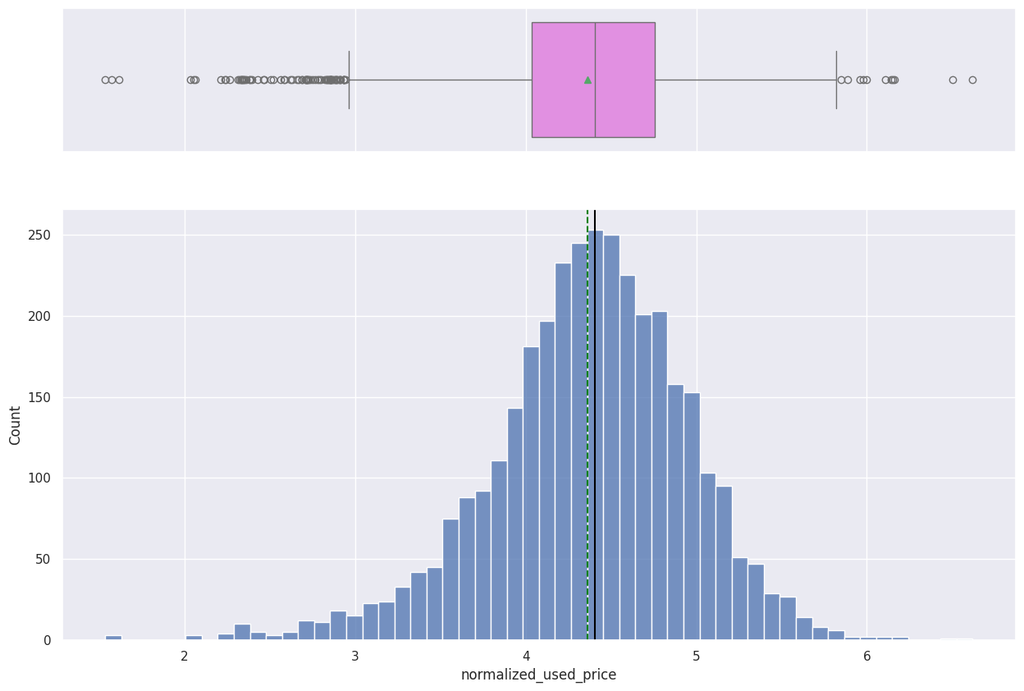

```python
histogram_boxplot(df, "normalized_used_price")
```

**Observation:**

**`normalized_new_price`**

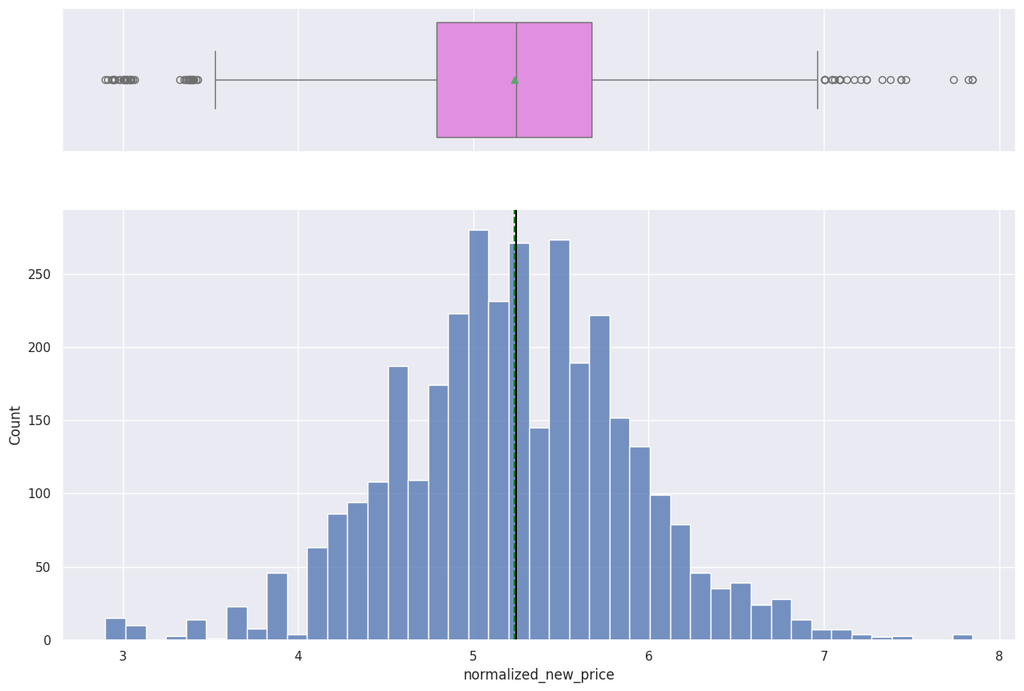

```python
histogram_boxplot(df, "normalized_new_price")
```

**Observation:**

- Normalized New Price: The distribution is somewhat similar to the used price, as expected, with a range of new device prices.

**`screen_size`**

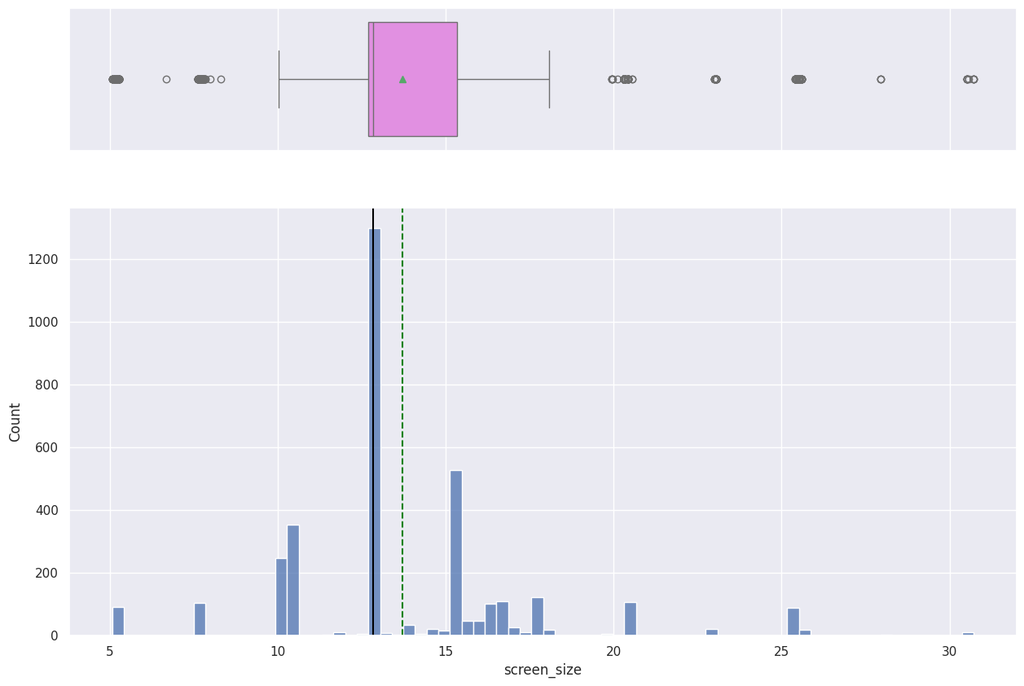

```python
histogram_boxplot(df, "screen_size")
```

**Observation:**

- The distribution of screen_size shows a wide range of screen sizes with a peak around 12-15 cm.
- The distribution appears somewhat bimodal, suggesting there might be two groups of devices based on screen size (e.g., phones and tablets).
- There are some outliers with very large screen sizes.

**`main_camera_mp`**

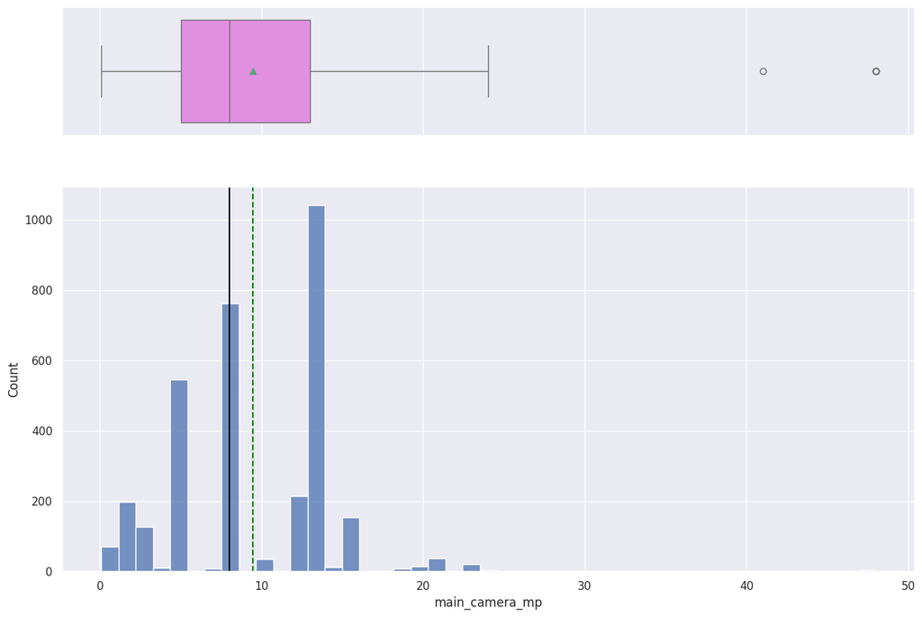

```python
histogram_boxplot(df, "main_camera_mp")
```

**Observation:**

- The distribution of main_camera_mp is skewed to the right, with a concentration of devices having camera resolutions around 8MP and 13MP.
- There are some devices with much higher camera resolutions, which appear as outliers on the box plot.
- The presence of missing values in this column was noted earlier and will need to be addressed during preprocessing.

**`selfie_camera_mp`**

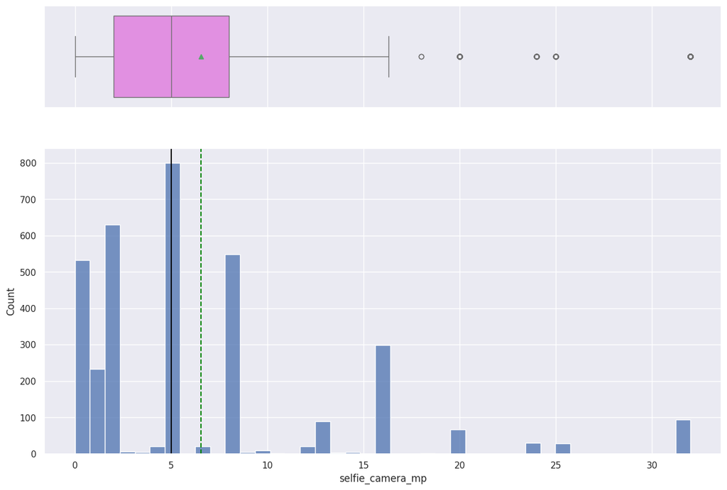

```python
histogram_boxplot(df, "selfie_camera_mp")
```

**Observation:**

- The distribution of selfie_camera_mp is also skewed to the right.
- Many devices have selfie cameras with resolutions of 5MP and 8MP.
- There are outliers with significantly higher selfie camera resolutions.
- A small number of missing values were observed for this feature.

**`int_memory`**

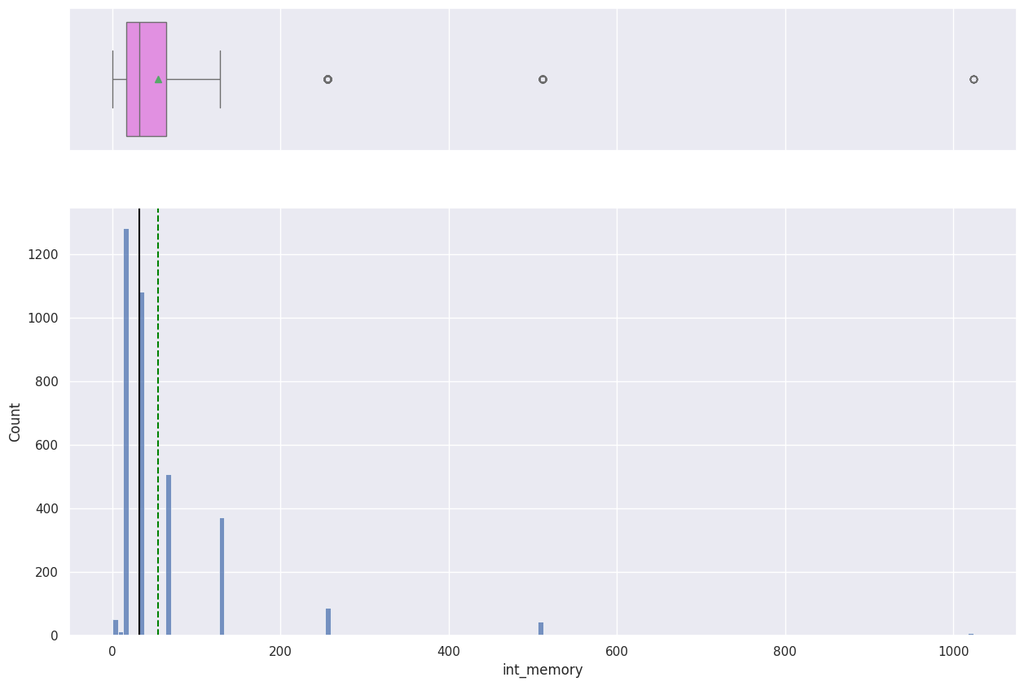

```python
histogram_boxplot(df, "int_memory")
```

**Observation:**

- The distribution of int_memory is highly skewed to the right.
- The majority of devices have internal memory capacities of 16GB, 32GB, and 64GB.
- There are a few devices with very large internal memory capacities (up to 1024GB), which are significant outliers.
- Missing values are present in this column.

**`ram`**

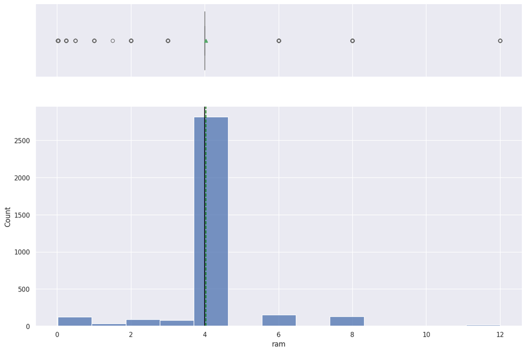

```python
histogram_boxplot(df, "ram")
```

**Observation:**

- The distribution of ram is also skewed to the right, but less severely than int_memory.
- The most common RAM capacities are 4GB and 6GB.
- There are devices with higher RAM capacities (up to 12GB), which appear as outliers.
- Missing values were identified in this column.

**`weight`**

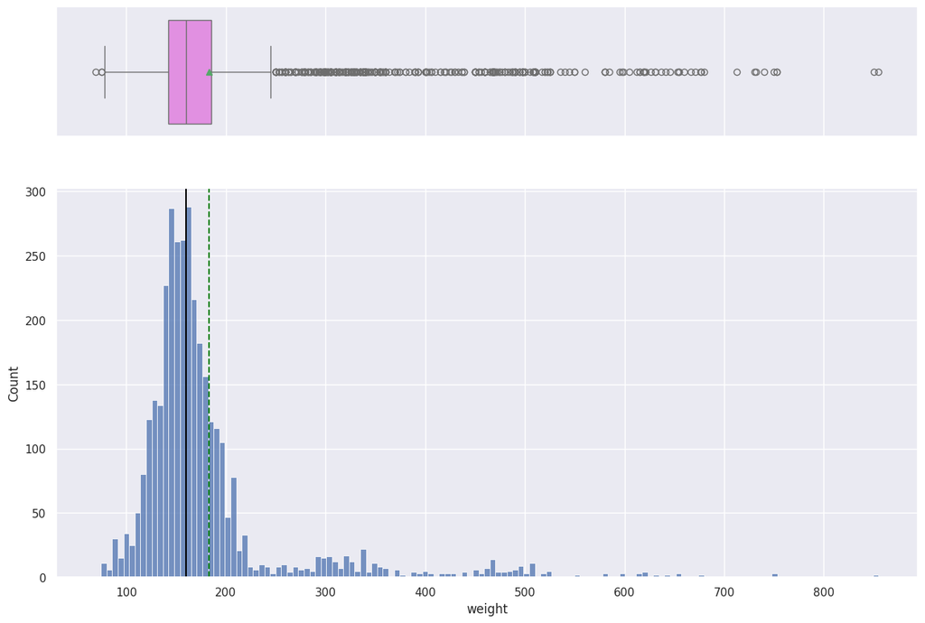

```python
histogram_boxplot(df, "weight")
```

**Observation:**

**`battery`**

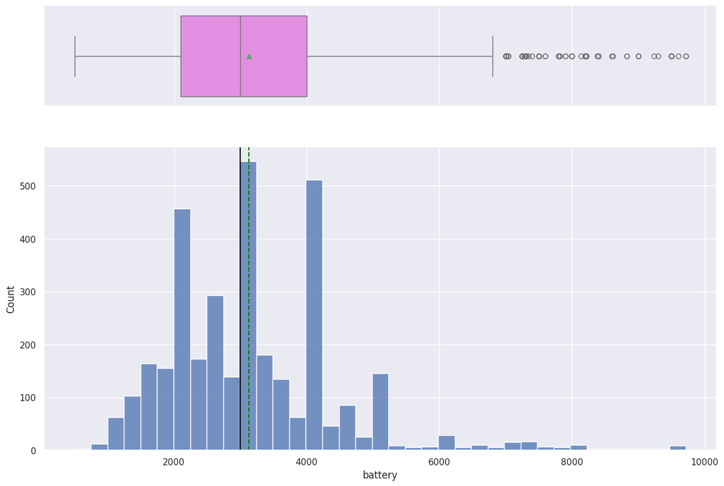

```python
histogram_boxplot(df, "battery")
```

**Observation:**

- The distribution of battery capacity is somewhat skewed to the right.
- Many devices have battery capacities around 3000mAh and 4000mAh.
- There are devices with significantly larger battery capacities, appearing as outliers.
- Missing values were found in this column.

**`days_used`**

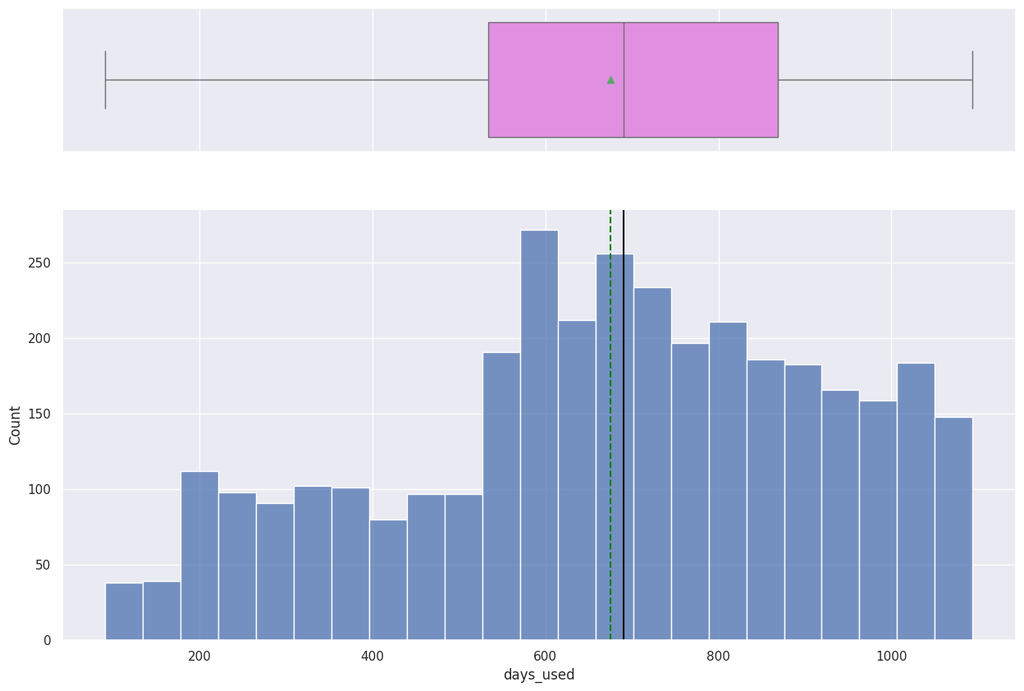

```python
histogram_boxplot(df, "days_used")
```

**Observation:**

- The distribution of days_used appears to be relatively more uniform compared to other numerical features, although there might be a slight skew to the left.
- The range of days used is from around 90 to over 1000 days.
- There do not appear to be significant outliers in this feature.
- There are no missing values in this column.

**`brand_name`**

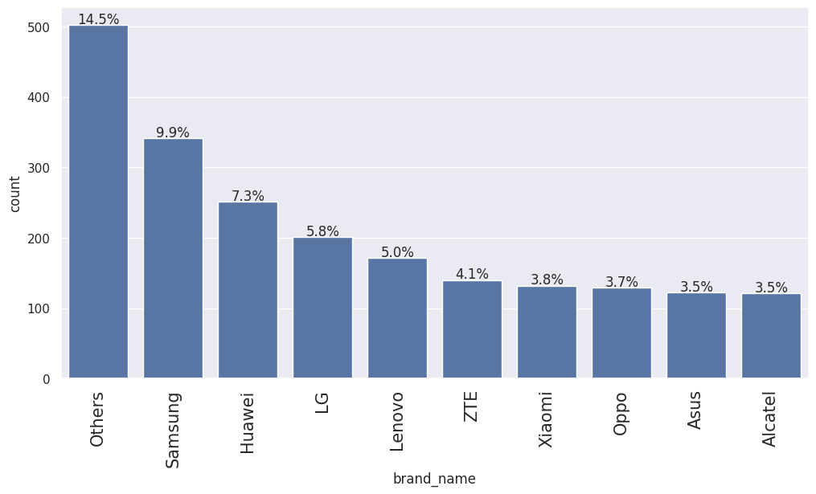

```python
labeled_barplot(df, "brand_name", perc=True, n=10)
```

**Observation:**

- The brand_name distribution shows that 'Others' is the most frequent category, which is expected as it groups less common brands.
- Among individual brands, 'Samsung', 'Huawei', and 'LG' appear to be the most prevalent in the dataset.
- The remaining brands have significantly lower frequencies.

**`os`**

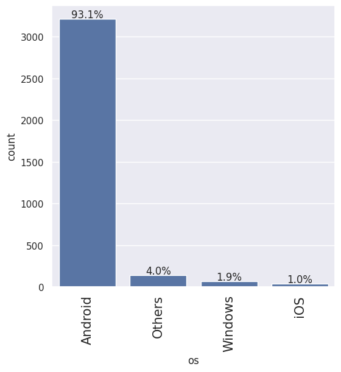

```python
labeled_barplot(df, "os", perc=True)
```

**Observation:**

- The os distribution clearly shows the dominance of Android devices in the dataset, accounting for over 90% of the observations.
- 'Others' is the second most frequent operating system, while Windows and Other iOS have minimal representation.

**`4g`**

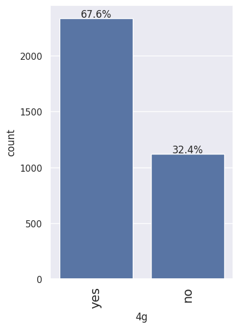

```python
labeled_barplot(df, "4g", perc=True)
```

**Observation:**

- The majority of devices in the dataset support 4G connectivity, which is expected for devices collected in 2021.
- A smaller percentage of devices do not have 4G capability.

**`5g`**

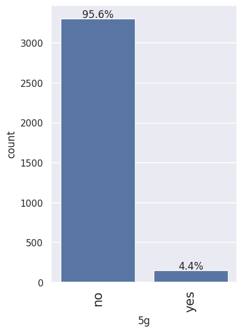

```python
labeled_barplot(df, "5g", perc=True)
```

**Observation:**

- As anticipated for data collected in 2021, the vast majority of devices in the dataset do not support 5G connectivity.
- A small percentage of devices are 5G enabled, reflecting the earlier stages of 5G adoption at the time of data collection.

**`release_year`**

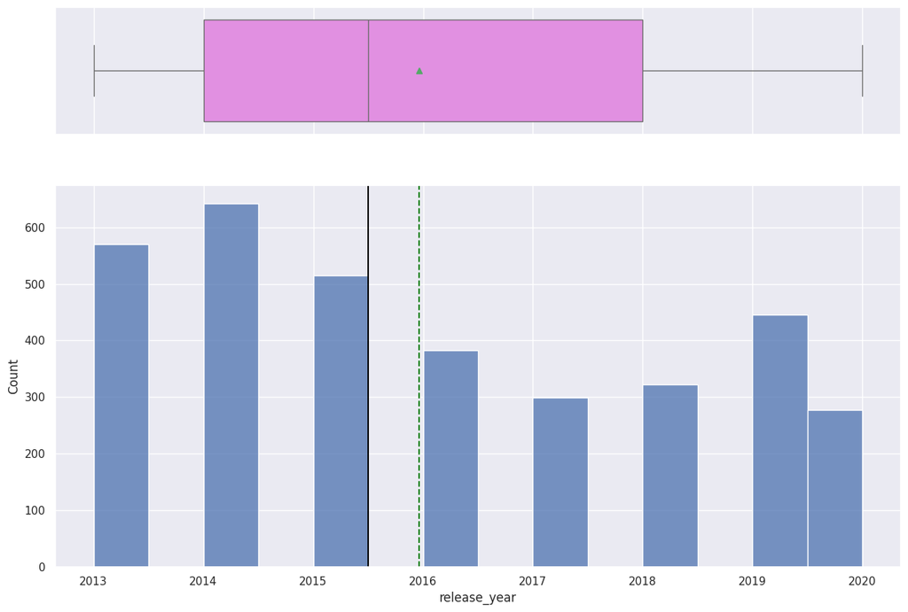

```python
histogram_boxplot(df, "release_year")
```

**Observation:**

### Bivariate Analysis

**`normalized_used_price` vs `days_used`**

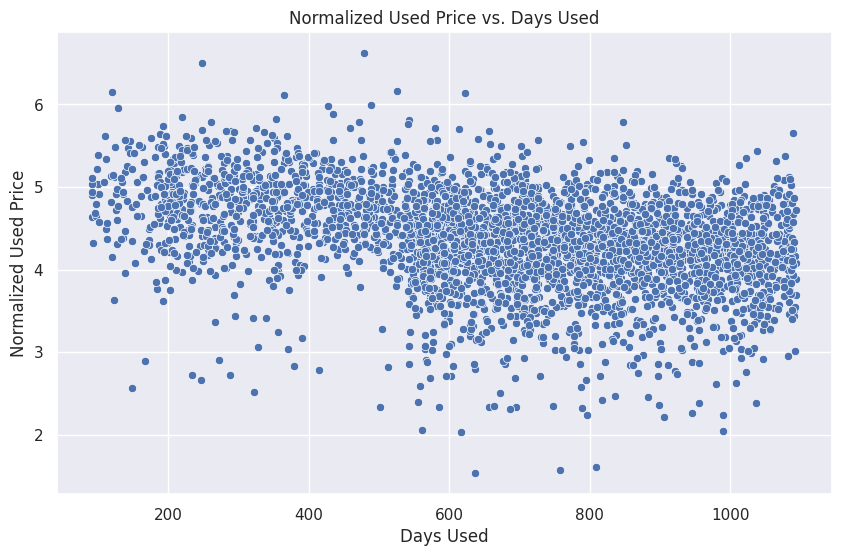

```python
plt.figure(figsize=(10, 6))
sns.scatterplot(x='days_used', y='normalized_used_price', data=df)
plt.title('Normalized Used Price vs. Days Used')
plt.xlabel('Days Used')
plt.ylabel('Normalized Used Price')
plt.show()
```

**Observation:**

**`normalized_used_price` vs `normalized_new_price`**

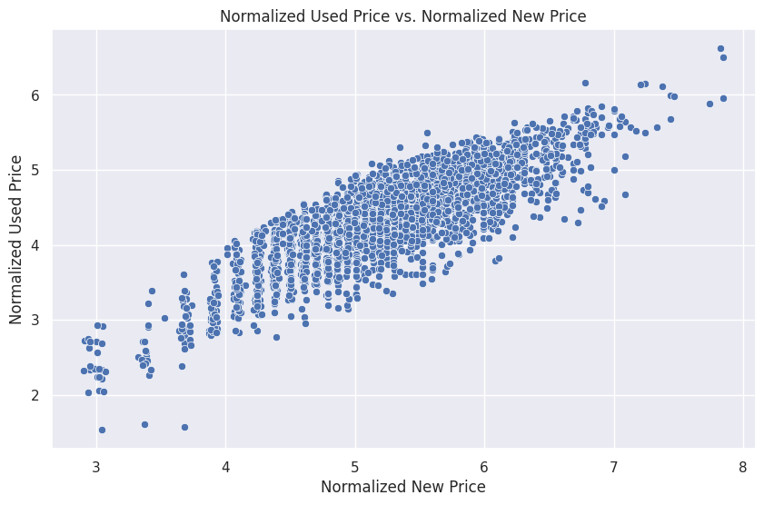

```python
plt.figure(figsize=(10, 6))
sns.scatterplot(x='normalized_new_price', y='normalized_used_price', data=df)
plt.title('Normalized Used Price vs. Normalized New Price')
plt.xlabel('Normalized New Price')
plt.ylabel('Normalized Used Price')
plt.show()
```

**Observation:**

- As expected, there is a strong positive linear relationship between the normalized new price and the normalized used price.
- Devices that were more expensive when new tend to have higher used prices.
- The scatter plot shows a clear upward trend, indicating that normalized new price is a significant factor in determining the normalized used price.

**`normalized_used_price` vs `int_memory`**

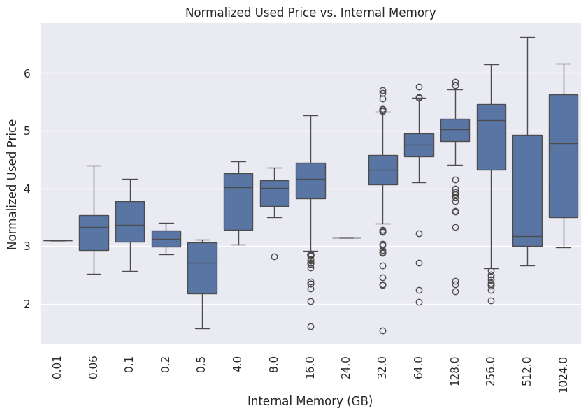

```python
plt.figure(figsize=(10, 6))
sns.boxplot(x='int_memory', y='normalized_used_price', data=df)
plt.title('Normalized Used Price vs. Internal Memory')
plt.xlabel('Internal Memory (GB)')
plt.ylabel('Normalized Used Price')
plt.xticks(rotation=90)
plt.show()
```

**Observation:**

- There appears to be a positive relationship between internal memory and normalized used price.
- Devices with higher internal memory capacities generally tend to have higher normalized used prices.
- There is variability in the used prices within each internal memory category, but the median price tends to increase as internal memory increases.

**`normalized_used_price` vs `ram`**

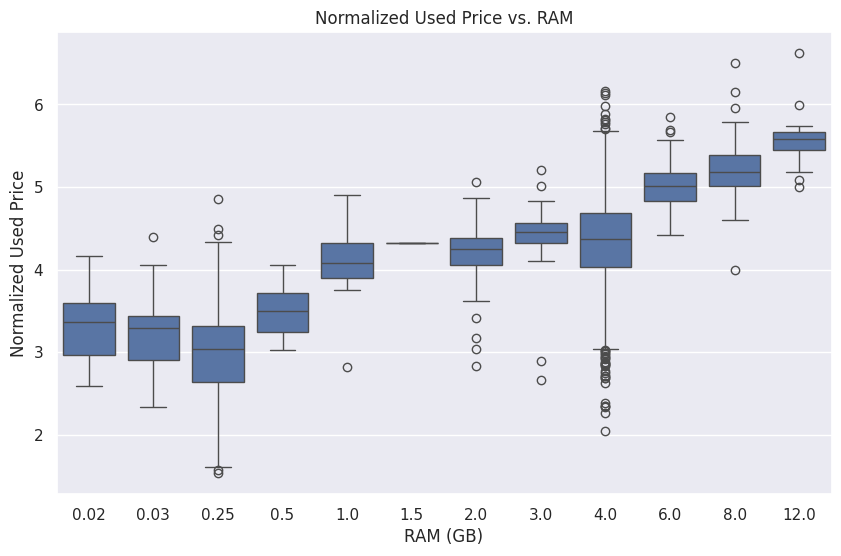

```python
plt.figure(figsize=(10, 6))
sns.boxplot(x='ram', y='normalized_used_price', data=df)
plt.title('Normalized Used Price vs. RAM')
plt.xlabel('RAM (GB)')
plt.ylabel('Normalized Used Price')
plt.show()
```

**Observation:**

**`normalized_used_price` vs `brand_name`**

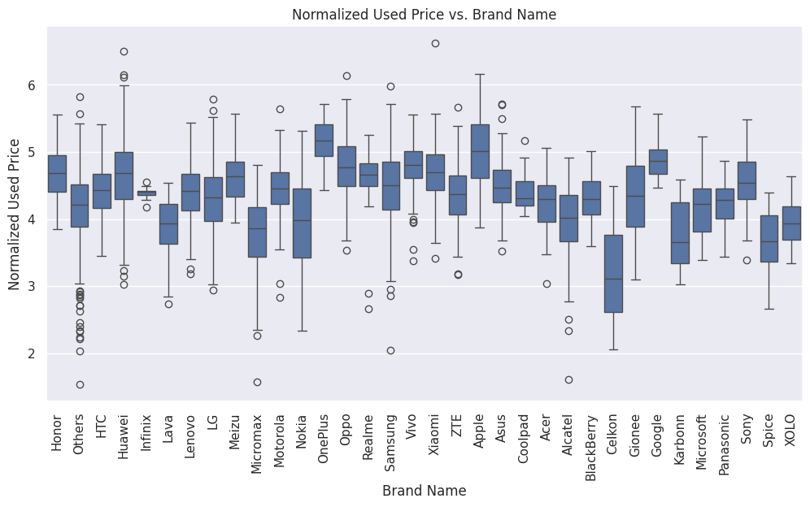

```python
plt.figure(figsize=(12, 6))
sns.boxplot(x='brand_name', y='normalized_used_price', data=df)
plt.title('Normalized Used Price vs. Brand Name')
plt.xlabel('Brand Name')
plt.ylabel('Normalized Used Price')
plt.xticks(rotation=90)
plt.show()
```

**Observation:**

**`normalized_used_price` vs `os`**

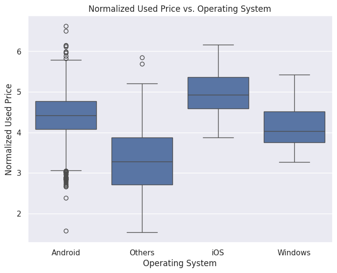

```python
plt.figure(figsize=(8, 6))
sns.boxplot(x='os', y='normalized_used_price', data=df)
plt.title('Normalized Used Price vs. Operating System')
plt.xlabel('Operating System')
plt.ylabel('Normalized Used Price')
plt.show()
```

**Observation:**

- The box plots indicate that devices running on iOS generally have higher normalized used prices compared to Android devices.
- The 'Other' and 'Windows' operating systems have very few data points, making it difficult to draw definitive conclusions about their price distributions.

**`normalized_used_price` vs `4g`**

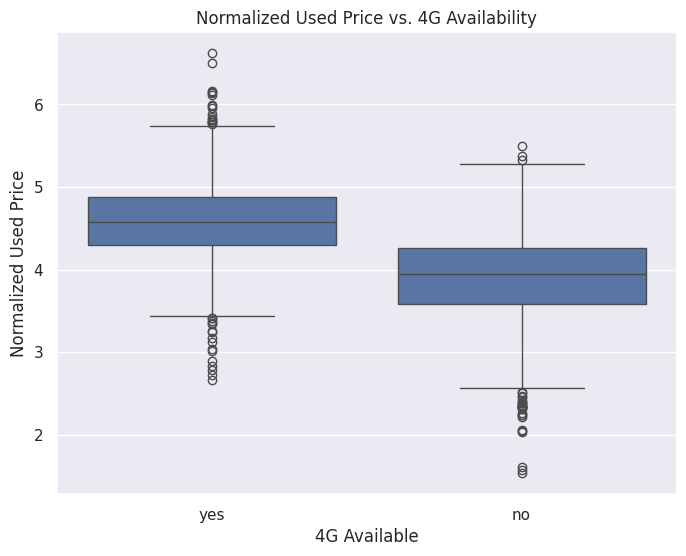

```python
plt.figure(figsize=(8, 6))
sns.boxplot(x='4g', y='normalized_used_price', data=df)
plt.title('Normalized Used Price vs. 4G Availability')
plt.xlabel('4G Available')
plt.ylabel('Normalized Used Price')
plt.show()
```

**Observation:**

**`normalized_used_price` vs `5g`**

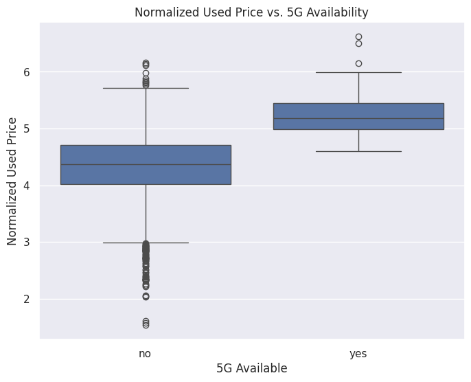

```python
plt.figure(figsize=(8, 6))
sns.boxplot(x='5g', y='normalized_used_price', data=df)
plt.title('Normalized Used Price vs. 5G Availability')
plt.xlabel('5G Available')
plt.ylabel('Normalized Used Price')
plt.show()
```

**Observation:**

- Devices with 5G capability tend to have noticeably higher normalized used prices compared to devices without 5G.
- This is expected as 5G is a newer technology and devices supporting it are generally more recent and higher-end, thus retaining more value in the used market.

**1. What does the distribution of normalized used device prices look like?**

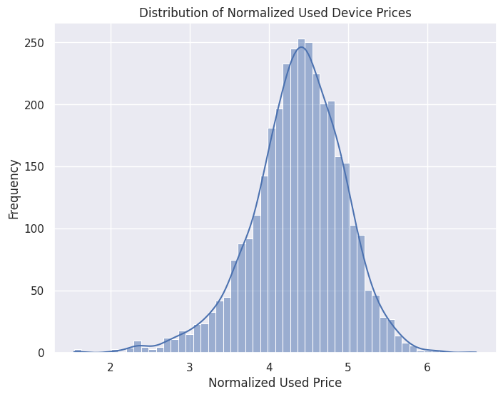

```python
plt.figure(figsize=(8, 6))
sns.histplot(data['normalized_used_price'], kde=True)
plt.title('Distribution of Normalized Used Device Prices')
plt.xlabel('Normalized Used Price')
plt.ylabel('Frequency')
plt.show()
```

**Observation:**

**2. What percentage of the used device market is dominated by Android devices?**

```python
android_percentage = (data['os'].value_counts(normalize=True) * 100)['Android']
print(f"Percentage of used device market dominated by Android devices: {android_percentage:.2f}%")
```

```
Percentage of used device market dominated by Android devices: 93.05%
```

**Observation:**

- Android devices dominate a large percentage of the used device market in this dataset.

**3. The amount of RAM is important for the smooth functioning of a device. How does the amount of RAM vary with the brand?**

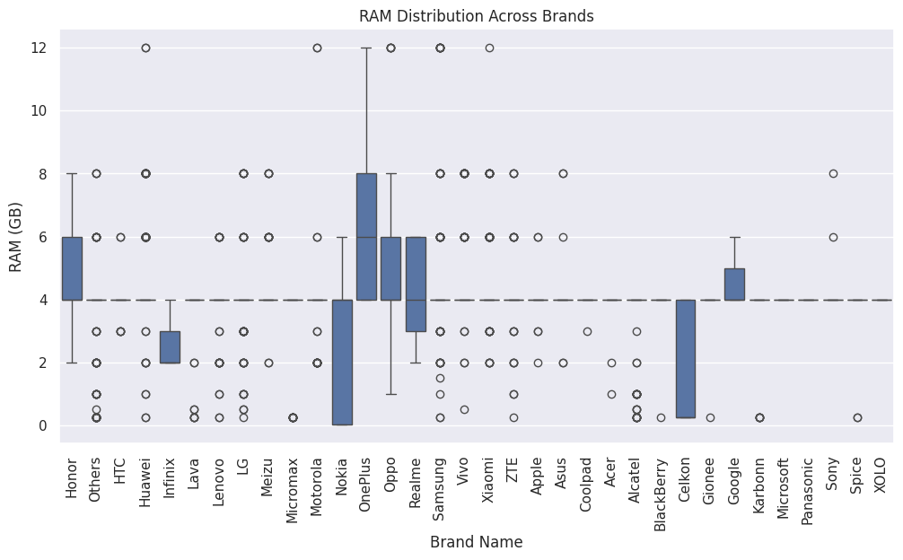

```python
plt.figure(figsize=(12, 6))
sns.boxplot(x='brand_name', y='ram', data=data)
plt.title('RAM Distribution Across Brands')
plt.xlabel('Brand Name')
plt.ylabel('RAM (GB)')
plt.xticks(rotation=90)
plt.show()
```

**Observation:**

- The box plot shows how the distribution of RAM varies across different brands.
- Some brands exhibit a wider range of RAM capacities, while others are more concentrated around a specific value.
- We can observe that some brands like 'Honor', 'OnePlus', and 'Oppo' tend to have devices with higher RAM capacities compared to brands like 'Nokia' or 'Celkon', although 'Nokia' and 'Celkon' shows a wide range of distribution.
- The 'infinix' and 'Goggle' shows a small distribution of RAM.

**4. A large battery often increases a device's weight, making it feel uncomfortable in the hands. How does the weight vary for phones and tablets offering large batteries (more than 4500 mAh)?**

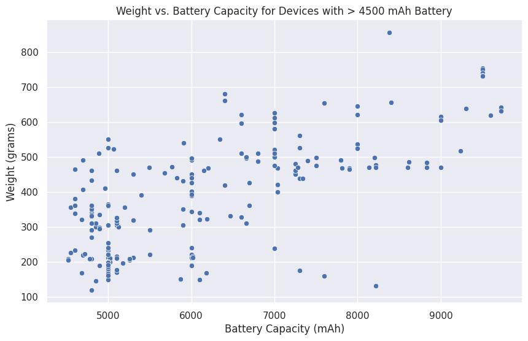

```python
# create a new dataframe of only those devices which have a large battery
large_battery_devices = data[data['battery'] > 4500]

plt.figure(figsize=(10, 6))
sns.scatterplot(x='battery', y='weight', data=large_battery_devices)
plt.title('Weight vs. Battery Capacity for Devices with > 4500 mAh Battery')
plt.xlabel('Battery Capacity (mAh)')
plt.ylabel('Weight (grams)')
plt.show()
```

**Observation:**

- The scatter plot shows the relationship between battery capacity and weight for devices with batteries larger than 4500 mAh.
- There appears to be a general positive correlation between battery capacity and weight, which is expected as larger batteries tend to be heavier.
- However, the relationship is not perfectly linear, suggesting that other factors also influence device weight.
- Some devices with large batteries manage to maintain relatively lower weights, while others with similar battery capacities are significantly heavier.

**5. Bigger screens are desirable for entertainment purposes as they offer a better viewing experience. How many phones and tablets are available across different brands with a screen size larger than 6 inches?**

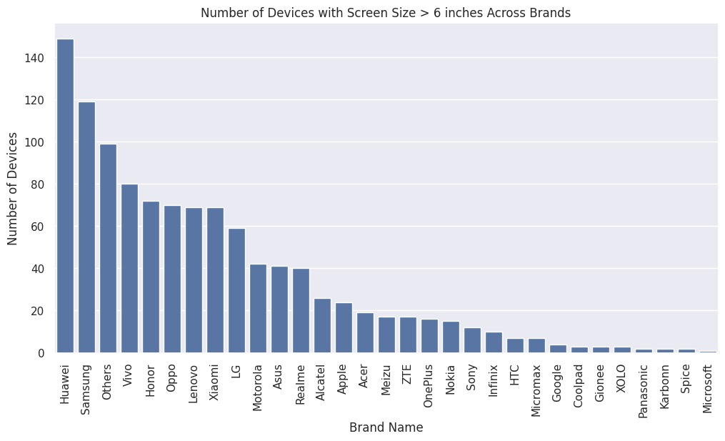

```python
# create a new dataframe for brands with large screen > 6
large_screen_devices = data[data['screen_size'] > 6 * 2.54] # Convert inches to cm (1 inch = 2.54 cm)
large_screen_by_brand = large_screen_devices['brand_name'].value_counts().reset_index()
large_screen_by_brand.columns = ['brand_name', 'count']

plt.figure(figsize=(12, 6))
sns.barplot(x='brand_name', y='count', data=large_screen_by_brand)
plt.title('Number of Devices with Screen Size > 6 inches Across Brands')
plt.xlabel('Brand Name')
plt.ylabel('Number of Devices')
plt.xticks(rotation=90)
plt.show()
```

**Observation:**

- The bar plot displays the count of devices with screen sizes larger than 6 inches for each brand.
- Some brands, like 'Huawei', and 'Samsung' have a higher number of devices with large screens in this dataset.
- The 'Others' category again shows a significant count, representing the aggregation of various brands.
- This visualization highlights which brands focus more on producing devices with larger displays.

**6.A lot of devices nowadays offer great selfie cameras, allowing us to capture our favorite moments with loved ones. What is the distribution of devices offering greater than 8MP selfie cameras across brands?**

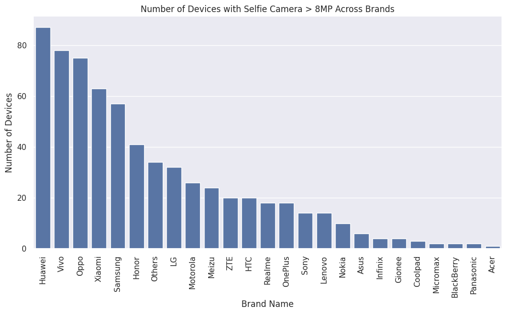

```python
# create a new dataframe for brands with high selfie camera >8
high_selfie_camera_devices = data[data['selfie_camera_mp'] > 8]
high_selfie_camera_by_brand = high_selfie_camera_devices['brand_name'].value_counts().reset_index()
high_selfie_camera_by_brand.columns = ['brand_name', 'count']

plt.figure(figsize=(12, 6))
sns.barplot(x='brand_name', y='count', data=high_selfie_camera_by_brand)
plt.title('Number of Devices with Selfie Camera > 8MP Across Brands')
plt.xlabel('Brand Name')
plt.ylabel('Number of Devices')
plt.xticks(rotation=90)
plt.show()
```

**Observation:**

- The bar plot shows the number of devices with selfie cameras greater than 8MP across different brands.
- Brands like 'Huawei', 'Viva', and 'Oppo' appear to have a higher number of devices with high-resolution selfie cameras.
- This indicates that these brands might be targeting consumers who prioritize high-quality front cameras.

**7. Which attributes are highly correlated with the normalized price of a used device?**

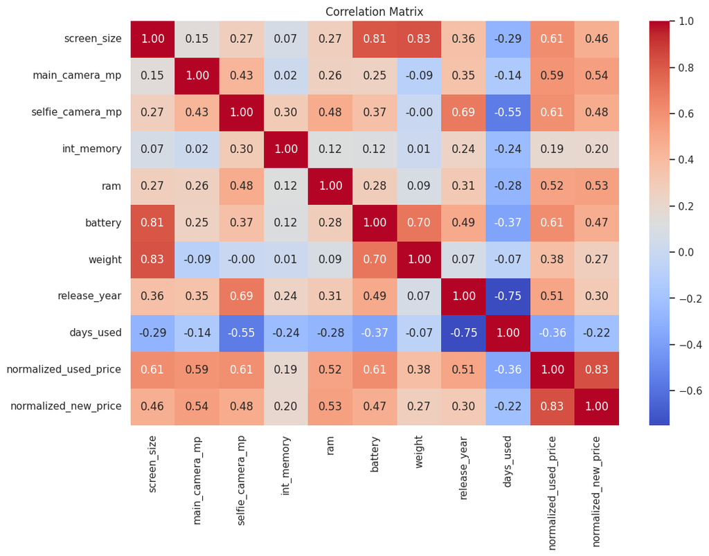

```python
plt.figure(figsize=(12, 8))
sns.heatmap(data.corr(numeric_only=True), annot=True, cmap='coolwarm', fmt=".2f")
plt.title('Correlation Matrix')
plt.show()
```

**Observation:**

## Data Preprocessing

- Missing value treatment
- Feature engineering (if needed)
- Outlier detection and treatment (if needed)
- Preparing data for modeling
- Any other preprocessing steps (if needed)

### Missing Value Imputation and Feature Engineering

- We will impute the missing values in the data by the column medians grouped by `release_year` and `brand_name`.
- We will create a new column `years_since_release` from the `release_year` column.
- We will consider the year of data collection, 2021, as the baseline.
- We will drop the `release_year` column.

```python
# let's create a copy of the data
df1 = df.copy()
```

```python
# checking for missing values
df1.isnull().sum()
```

|  | 0 |
| --- | --- |
| brand_name | 0 |
| os | 0 |
| screen_size | 0 |
| 4g | 0 |
| 5g | 0 |
| main_camera_mp | 179 |
| selfie_camera_mp | 2 |
| int_memory | 4 |
| ram | 4 |
| battery | 6 |
| weight | 7 |
| release_year | 0 |
| days_used | 0 |
| normalized_used_price | 0 |
| normalized_new_price | 0 |

**dtype:** int64

```python
# Impute missing values in cols_impute with median by grouping the data on release year
cols_impute = [
    "main_camera_mp",
    "selfie_camera_mp",
    "int_memory",
    "ram",
    "battery",
    "weight",
]

if 'release_year' in df1.columns:
    for col in cols_impute:
        df1[col] = df1[col].fillna(
            value=df1.groupby(['release_year'])[col].transform("median")
        )

# checking for missing values after grouping by release_year
print("Missing values after imputing by release_year:")
print(df1.isnull().sum())

# Now proceed with feature engineering (creating years_since_release)
if 'release_year' in df1.columns:
    df1["years_since_release"] = 2021 - df1["release_year"]
    df1.drop("release_year", axis=1, inplace=True)
    print("\nDescription of years_since_release:")
    print(df1["years_since_release"].describe()) # Corrected typo here

# Further imputation using brand_name for remaining missing values (if any)
cols_impute_brand = [
    "main_camera_mp",
    "selfie_camera_mp",
    "battery",
    "weight",
    "int_memory", # Added int_memory and ram to potentially be imputed by brand if release_year grouping didn't fill all
    "ram",
]

if 'brand_name' in df1.columns:
    for col in cols_impute_brand:
        df1[col] = df1[col].fillna(
            value=df1.groupby(['brand_name'])[col].transform("median")
        )

# checking for missing values after grouping by brand_name
print("\nMissing values after imputing by brand_name:")
print(df1.isnull().sum())


# Finally, impute any remaining missing values with the overall median
final_cols_impute = [
    "main_camera_mp",
    "selfie_camera_mp",
    "int_memory",
    "ram",
    "battery",
    "weight",
]
for col in final_cols_impute:
     df1[col] = df1[col].fillna(df1[col].median())

# Final check for missing values
print("\nMissing values after final imputation:")
print(df1.isnull().sum())
```

```
Missing values after imputing by release_year:
brand_name               0
os                       0
screen_size              0
4g                       0
5g                       0
main_camera_mp           0
selfie_camera_mp         0
int_memory               0
ram                      0
battery                  0
weight                   0
days_used                0
normalized_used_price    0
normalized_new_price     0
years_since_release      0
dtype: int64

Missing values after imputing by brand_name:
brand_name               0
os                       0
screen_size              0
4g                       0
5g                       0
main_camera_mp           0
selfie_camera_mp         0
int_memory               0
ram                      0
battery                  0
weight                   0
days_used                0
normalized_used_price    0
normalized_new_price     0
years_since_release      0
dtype: int64

Missing values after final imputation:
brand_name               0
os                       0
screen_size              0
4g                       0
5g                       0
main_camera_mp           0
selfie_camera_mp         0
int_memory               0
ram                      0
battery                  0
weight                   0
days_used                0
normalized_used_price    0
normalized_new_price     0
years_since_release      0
dtype: int64
```

```python
# check for missing values
df1.isnull().sum()
```

|  | 0 |
| --- | --- |
| brand_name | 0 |
| os | 0 |
| screen_size | 0 |
| 4g | 0 |
| 5g | 0 |
| main_camera_mp | 0 |
| selfie_camera_mp | 0 |
| int_memory | 0 |
| ram | 0 |
| battery | 0 |
| weight | 0 |
| days_used | 0 |
| normalized_used_price | 0 |
| normalized_new_price | 0 |
| years_since_release | 0 |

**dtype:** int64

**Observation:**

- A new copy of the original data, df1, has been created.
- The missing values in the specified numerical columns of df1 have been imputed using the median.
- The output confirms that there are no more missing values in these columns in the df1 DataFrame.

### Outlier Check

- Let's check for outliers in the data.

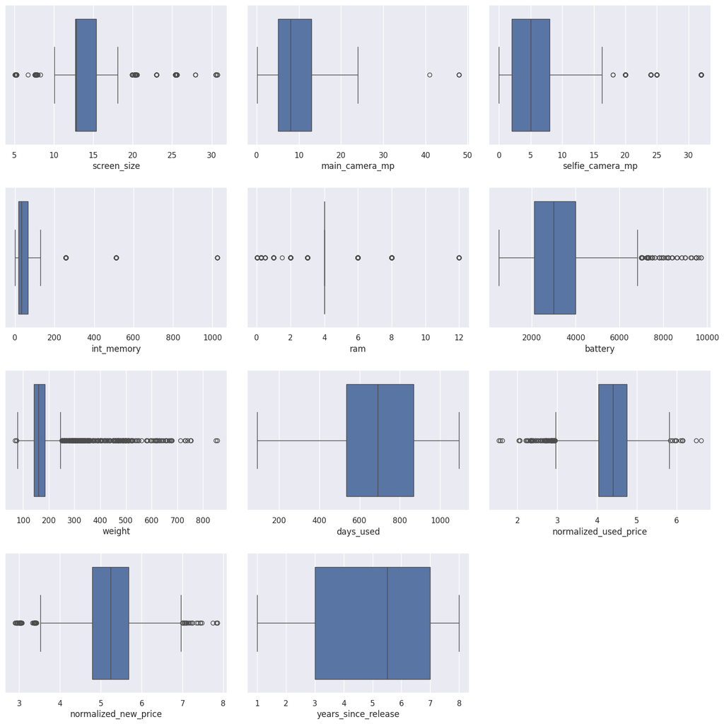

```python
# outlier detection using boxplot
num_cols = df1.select_dtypes(include=np.number).columns.tolist()

plt.figure(figsize=(15, 15))

for i, variable in enumerate(num_cols):
    plt.subplot(4, 3, i + 1)
    sns.boxplot(data=df1, x=variable)
    plt.tight_layout(pad=2)

plt.show()
```

**observations:**

- The boxplots reveal that several numerical features, particularly those related to specifications like camera megapixels, internal memory, RAM, battery, and weight, have distributions skewed to the right with the presence of outliers. screen_size also shows outliers on the higher end. normalized_used_price, normalized_new_price, and days_used appear more symmetrically distributed, although the price features have some high-end outliers. These observations are important for understanding the data's characteristics and considering potential outlier treatment during preprocessing.

### Data Preparation for modeling

```python
# define the dependent and independent variables
X = df1.drop('normalized_used_price', axis=1)
y = df1['normalized_used_price']

print(X.head())
print()
print(y.head())
```

```
  brand_name       os  screen_size   4g   5g  main_camera_mp  \
0      Honor  Android        14.50  yes   no            13.0
1      Honor  Android        17.30  yes  yes            13.0
2      Honor  Android        16.69  yes  yes            13.0
3      Honor  Android        25.50  yes  yes            13.0
4      Honor  Android        15.32  yes   no            13.0

   selfie_camera_mp  int_memory  ram  battery  weight  days_used  \
0               5.0        64.0  3.0   3020.0   146.0        127
1              16.0       128.0  8.0   4300.0   213.0        325
2               8.0       128.0  8.0   4200.0   213.0        162
3               8.0        64.0  6.0   7250.0   480.0        345
4               8.0        64.0  3.0   5000.0   185.0        293

   normalized_new_price  years_since_release
0              4.715100                    1
1              5.519018                    1
2              5.884631                    1
3              5.630961                    1
4              4.947837                    1

0    4.307572
1    5.162097
2    5.111084
3    5.135387
4    4.389995
Name: normalized_used_price, dtype: float64
```

```python
# let's add the intercept to data
X = sm.add_constant(X)
```

```python
# creating dummy variables
X = pd.get_dummies(
    X,
    columns=X.select_dtypes(include=["object", "category"]).columns.tolist(),
    drop_first=True,
)

X.head()
```

|  | const | screen_size | main_camera_mp | selfie_camera_mp | int_memory | ram | battery | weight | days_used | normalized_new_price | ... | brand_name_Spice | brand_name_Vivo | brand_name_XOLO | brand_name_Xiaomi | brand_name_ZTE | os_Others | os_Windows | os_iOS | 4g_yes | 5g_yes |
| --- | --- | --- | --- | --- | --- | --- | --- | --- | --- | --- | --- | --- | --- | --- | --- | --- | --- | --- | --- | --- | --- |
| 0 | 1.0 | 14.50 | 13.0 | 5.0 | 64.0 | 3.0 | 3020.0 | 146.0 | 127 | 4.715100 | ... | False | False | False | False | False | False | False | False | True | False |
| 1 | 1.0 | 17.30 | 13.0 | 16.0 | 128.0 | 8.0 | 4300.0 | 213.0 | 325 | 5.519018 | ... | False | False | False | False | False | False | False | False | True | True |
| 2 | 1.0 | 16.69 | 13.0 | 8.0 | 128.0 | 8.0 | 4200.0 | 213.0 | 162 | 5.884631 | ... | False | False | False | False | False | False | False | False | True | True |
| 3 | 1.0 | 25.50 | 13.0 | 8.0 | 64.0 | 6.0 | 7250.0 | 480.0 | 345 | 5.630961 | ... | False | False | False | False | False | False | False | False | True | True |
| 4 | 1.0 | 15.32 | 13.0 | 8.0 | 64.0 | 3.0 | 5000.0 | 185.0 | 293 | 4.947837 | ... | False | False | False | False | False | False | False | False | True | False |

5 rows × 49 columns

```python
# splitting the data in 70:30 ratio for train to test data

x_train, x_test, y_train, y_test = train_test_split(
    X, y, test_size=0.3, random_state=0
)
```

```python
print("Number of rows in train data =", x_train.shape[0])
print("Number of rows in test data =", x_test.shape[0])
```

```
Number of rows in train data = 2417
Number of rows in test data = 1037
```